# Análise Exploratória de Séries Financeiras com o R

## Introdução

Este curso tem o objetivo de ensinar importação de dados financeiros como cotações das ações da B3, manipulação de dados em série temporal, como calcular as estatísticas descritivas e como realizar análise exploratória de dados para séries financeiras.

O pré-requisito deste curso é conhecer as operações básicas do R e estatística descritiva.

## Conteúdo

O curso é dividido em 4 partes, são elas:

1. Importação de dados
2. Manipulação de dados
3. Estatística descritiva
4. Análise exploratória de dados

### 1. Importação de dados com o pacote *quantmod*

O pacote mais sólido para importar dados de cotações de ações é o *quantmod* (Quantitative Financial Modelling Framework). É possível criar um ambiente no qual *quants* possam analisar e desenvolver modelos para *trading*.

Inicialmente, vamos carregar o pacote *quantmod*:

```r
library(quantmod)
```

Uma vez carregado o pacote, podemos realizar o download das cotações diárias. Inicialmente, vamos baixar os dados do Ibov para o ano de 2019. A função para realizar o download dos dados é `getSymbols()` com os argumentos: ticker(s), from (data de início), to (data final), periodicity (periodicidade dos dados). A periodicidade pode ser diária (daily), semanal (weekly) e mensal (monthly).

```r
getSymbols("^BVSP", from = "2019-01-01", to = Sys.Date(), periodicity='daily')
```

[output not shown]

```
[1] "^BVSP"
```

Perceba que eu não salvei em nenhum objeto, porém quando olho o meu ambiente, percebo que existe um objeto chamado **BVSP**. Agora podemos visualizar as 6 primeiras linhas dos dados usando a função head:

```r
head(BVSP)
```

```
           BVSP.Open BVSP.High BVSP.Low BVSP.Close BVSP.Volume BVSP.Adjusted
2019-01-02     87887     91479    87536      91012     5615400         91012
2019-01-03     91011     91596    89922      91564     6066200         91564
2019-01-04     91577     92701    90824      91841     5322100         91841
2019-01-07     91845     92552    91288      91699     4565000         91699
2019-01-08     91699     92231    91064      92032     4496500         92032
2019-01-09     92033     93626    92028      93613     5011400         93613
```

O objeto é `xts` que tem característica de série temporal. Vejamos a estrutura dele:

```r
str(BVSP)
```

```
An ‘xts’ object on 2019-01-02/2019-09-19 containing:
  Data: num [1:180, 1:6] 87887 91011 91577 91845 91699 ...
 - attr(*, "dimnames")=List of 2
  ..$ : NULL
  ..$ : chr [1:6] "BVSP.Open" "BVSP.High" "BVSP.Low" "BVSP.Close" ...
  Indexed by objects of class: [Date] TZ: UTC
  xts Attributes:
List of 2
 $ src    : chr "yahoo"
 $ updated: POSIXct[1:1], format: "2019-09-20 22:58:39"
```

Podemos acessar qualquer variável desse objeto, como o valor de abertura, fechamento, volume etc, por meio do operador `$`:

```r
head(BVSP$BVSP.Close)
```

```
           BVSP.Close
2019-01-02      91012
2019-01-03      91564
2019-01-04      91841
2019-01-07      91699
2019-01-08      92032
2019-01-09      93613
```

```r
head(BVSP$BVSP.Volume)
```

```
           BVSP.Volume
2019-01-02     5615400
2019-01-03     6066200
2019-01-04     5322100
2019-01-07     4565000
2019-01-08     4496500
2019-01-09     5011400
```

Vamos visualizar um gráfico da série de Fechamento:

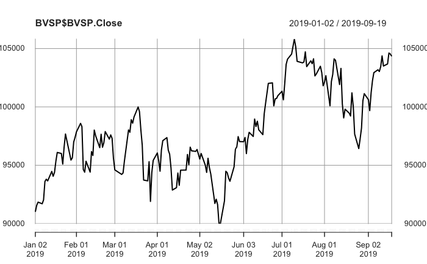

```r
plot(BVSP$BVSP.Close)
```

Perceba que o gráfico já foi estruturado para o objeto `xts` do pacote `quantmod`.

Esse foi um exemplo simples. A aula de hoje trabalhará com mais ações. Antes de iniciar o download das demais informações, é importante limpar o ambiente.

```r
rm(list = ls())
```

#### 1.1 Download das cotações, volume e retorno ajustado

```r
acoes <- c("EMBR3.SA", "ITUB3.SA", "PETR3.SA","VALE3.SA")
env <- new.env()
getSymbols(acoes, env = env, from = "2010-01-01", periodicity = "daily")
```

```
[1] "EMBR3.SA" "ITUB3.SA" "PETR3.SA" "VALE3.SA"
```

Visualizaremos, a seguir, os dados baixados:

```r
head(env$EMBR3.SA)
```

```
           EMBR3.SA.Open EMBR3.SA.High EMBR3.SA.Low EMBR3.SA.Close EMBR3.SA.Volume
2010-01-04          9.58          9.87         9.53           9.87         2967000
2010-01-05          9.90          9.93         9.59           9.64         2909200
2010-01-06          9.55          9.67         9.45           9.60         4814900
2010-01-07          9.58          9.59         9.47           9.47         1458700
2010-01-08          9.53          9.54         9.34           9.45         3497500
2010-01-11          9.53          9.54         9.40           9.54         1904000
           EMBR3.SA.Adjusted
2010-01-04          8.911546
2010-01-05          8.703883
2010-01-06          8.667766
2010-01-07          8.550391
2010-01-08          8.532333
2010-01-11          8.613593
```

```r
head(env$ITUB3.SA)
```

```
           ITUB3.SA.Open ITUB3.SA.High ITUB3.SA.Low ITUB3.SA.Close ITUB3.SA.Volume
2010-01-04       13.6557       14.1384      13.6557        14.1384          627001
2010-01-05       14.1156       14.1611      13.9562        14.1611          183159
2010-01-06       14.1611       14.1611      13.9654        14.1611          116396
2010-01-07       14.0564       14.0701      13.9471        14.0245          136820
2010-01-08       13.9745       14.0154      13.7195        13.8652           95972
2010-01-11       13.8060       13.9335      13.3006        13.6603          157684
           ITUB3.SA.Adjusted
2010-01-04         10.059744
2010-01-05         10.075897
2010-01-06         10.075897
2010-01-07          9.978700
2010-01-08          9.865356
2010-01-11          9.719567
```

```r
head(env$PETR3.SA)
```

```
           PETR3.SA.Open PETR3.SA.High PETR3.SA.Low PETR3.SA.Close PETR3.SA.Volume
2010-01-04         41.70         41.86        41.40          41.65         4892000
2010-01-05         41.85         41.86        41.15          41.40         3828900
2010-01-06         41.19         42.05        41.05          41.81         3434000
2010-01-07         41.51         42.87        41.30          41.56         2794400
2010-01-08         41.80         41.86        41.14          41.25         3116900
2010-01-11         41.51         41.89        41.12          41.29         3400300
           PETR3.SA.Adjusted
2010-01-04          37.78718
2010-01-05          37.56036
2010-01-06          37.93234
2010-01-07          37.70552
2010-01-08          37.42428
2010-01-11          37.46057
```

```r
head(env$VALE3.SA)
```

```
           VALE3.SA.Open VALE3.SA.High VALE3.SA.Low VALE3.SA.Close VALE3.SA.Volume
2010-01-04         50.19         51.49        49.80          51.49         2381400
2010-01-05         51.54         52.54        51.24          51.97         3001800
2010-01-06         52.00         53.37        51.78          53.07         2742800
2010-01-07         52.51         53.54        52.50          53.29         2543100
2010-01-08         53.30         54.24        53.00          53.81         2444500
2010-01-11         54.60         54.60        53.34          53.65         2785300
           VALE3.SA.Adjusted
2010-01-04          35.55403
2010-01-05          35.88548
2010-01-06          36.64504
2010-01-07          36.79694
2010-01-08          37.15601
2010-01-11          37.04552
```

### 2. Manipulação de dados

É possível automatizar o processo acima a partir da função `lapply` que realiza um loop. Esse loop aplicará a função `head` em cada objeto do meu ambiente `env`. Veja a seguir:

```r
# vendo o cabeçalho - iterando pelos objetos do ambiente
lapply(env, head)
```

```
$EMBR3.SA
           EMBR3.SA.Open EMBR3.SA.High EMBR3.SA.Low EMBR3.SA.Close EMBR3.SA.Volume
2010-01-04          9.58          9.87         9.53           9.87         2967000
2010-01-05          9.90          9.93         9.59           9.64         2909200
2010-01-06          9.55          9.67         9.45           9.60         4814900
2010-01-07          9.58          9.59         9.47           9.47         1458700
2010-01-08          9.53          9.54         9.34           9.45         3497500
2010-01-11          9.53          9.54         9.40           9.54         1904000
           EMBR3.SA.Adjusted
2010-01-04          8.911546
2010-01-05          8.703883
2010-01-06          8.667766
2010-01-07          8.550391
2010-01-08          8.532333
2010-01-11          8.613593

$PETR3.SA
           PETR3.SA.Open PETR3.SA.High PETR3.SA.Low PETR3.SA.Close PETR3.SA.Volume
2010-01-04         41.70         41.86        41.40          41.65         4892000
2010-01-05         41.85         41.86        41.15          41.40         3828900
2010-01-06         41.19         42.05        41.05          41.81         3434000
2010-01-07         41.51         42.87        41.30          41.56         2794400
2010-01-08         41.80         41.86        41.14          41.25         3116900
2010-01-11         41.51         41.89        41.12          41.29         3400300
           PETR3.SA.Adjusted
2010-01-04          37.78718
2010-01-05          37.56036
2010-01-06          37.93234
2010-01-07          37.70552
2010-01-08          37.42428
2010-01-11          37.46057

$VALE3.SA
           VALE3.SA.Open VALE3.SA.High VALE3.SA.Low VALE3.SA.Close VALE3.SA.Volume
2010-01-04         50.19         51.49        49.80          51.49         2381400
2010-01-05         51.54         52.54        51.24          51.97         3001800
2010-01-06         52.00         53.37        51.78          53.07         2742800
2010-01-07         52.51         53.54        52.50          53.29         2543100
2010-01-08         53.30         54.24        53.00          53.81         2444500
2010-01-11         54.60         54.60        53.34          53.65         2785300
```

[output cut: 8 more lines]

```
$ITUB3.SA
           ITUB3.SA.Open ITUB3.SA.High ITUB3.SA.Low ITUB3.SA.Close ITUB3.SA.Volume
2010-01-04       13.6557       14.1384      13.6557        14.1384          627001
2010-01-05       14.1156       14.1611      13.9562        14.1611          183159
2010-01-06       14.1611       14.1611      13.9654        14.1611          116396
2010-01-07       14.0564       14.0701      13.9471        14.0245          136820
2010-01-08       13.9745       14.0154      13.7195        13.8652           95972
2010-01-11       13.8060       13.9335      13.3006        13.6603          157684
           ITUB3.SA.Adjusted
2010-01-04         10.059744
2010-01-05         10.075897
2010-01-06         10.075897
2010-01-07          9.978700
2010-01-08          9.865356
2010-01-11          9.719567
```

Perceba que temos cotações de abertura; a cotação mais alta do dia e mais baixa do dia; a cotação de fechamento; o volume negociado e o retorno ajustado.

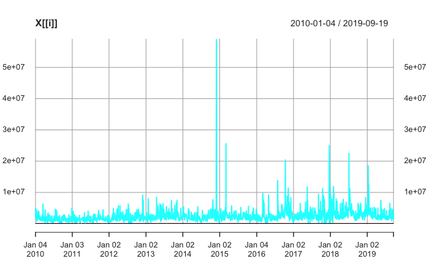

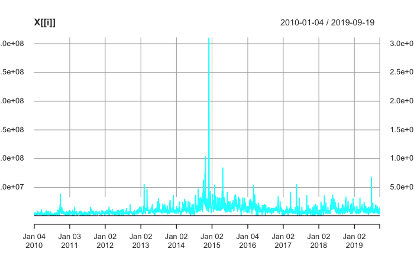

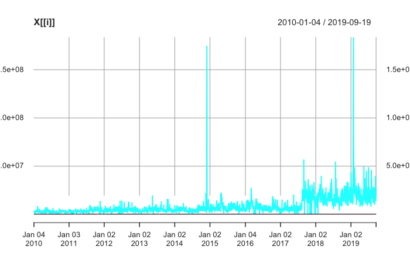

```
NA
```

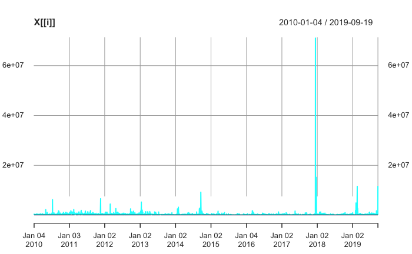

```r
lapply(env, plot)
```

Vamos extrair as informações do ambiente e salvá-las em tabelas individuais. É importante salvar em uma lista.

```r
lista <- list(EMBR3 = env$EMBR3.SA, ITUB3 = env$ITUB3.SA,
              PETR3 = env$PETR3.SA, VALE3 = env$VALE3.SA)
```

Agora vamos selecionar a cotação de abertura e de fechamento e o retorno ajustado. Em seguida, salvaremos os dados em uma nova lista, chamada de `listaf`. Após, poderemos extrair as tabelas, individualmente, realizando um loop na `listaf` de forma que aplicaremos um `assign` para cada acão, usando o Ticker como o nome de cada objeto.

```r
# criar um vetor para selecionar as colunas números 1, 4 e 6
cols = c(1,4,6)

# visualizar a forma de fazer indexing em listas lista[[i]][r,c]
#lista[[1]][1:6,cols]

# vamos extrair apenas as colunas 1 e 6 e salvar no objeto listaf que é uma lista
listaf <- lapply(lista, function(x) x[,cols])

# visualizar a estrutura de listaf
str(listaf)
```

```
List of 4
 $ EMBR3:An ‘xts’ object on 2010-01-04/2019-09-19 containing:
  Data: num [1:2412, 1:3] 9.58 9.9 9.55 9.58 9.53 9.53 9.5 9.9 9.71 9.61 ...
 - attr(*, "dimnames")=List of 2
  ..$ : NULL
  ..$ : chr [1:3] "EMBR3.SA.Open" "EMBR3.SA.Close" "EMBR3.SA.Adjusted"
  Indexed by objects of class: [Date] TZ: UTC
  xts Attributes:
List of 2
  ..$ src    : chr "yahoo"
  ..$ updated: POSIXct[1:1], format: "2019-09-20 22:58:40"
 $ ITUB3:An ‘xts’ object on 2010-01-04/2019-09-19 containing:
  Data: num [1:2412, 1:3] 13.7 14.1 14.2 14.1 14 ...
 - attr(*, "dimnames")=List of 2
  ..$ : NULL
  ..$ : chr [1:3] "ITUB3.SA.Open" "ITUB3.SA.Close" "ITUB3.SA.Adjusted"
  Indexed by objects of class: [Date] TZ: UTC
  xts Attributes:
List of 2
  ..$ src    : chr "yahoo"
  ..$ updated: POSIXct[1:1], format: "2019-09-20 22:58:41"
 $ PETR3:An ‘xts’ object on 2010-01-04/2019-09-19 containing:
  Data: num [1:2412, 1:3] 41.7 41.8 41.2 41.5 41.8 ...
 - attr(*, "dimnames")=List of 2
  ..$ : NULL
  ..$ : chr [1:3] "PETR3.SA.Open" "PETR3.SA.Close" "PETR3.SA.Adjusted"
  Indexed by objects of class: [Date] TZ: UTC
  xts Attributes:
List of 2
  ..$ src    : chr "yahoo"
  ..$ updated: POSIXct[1:1], format: "2019-09-20 22:58:42"
 $ VALE3:An ‘xts’ object on 2010-01-04/2019-09-19 containing:
  Data: num [1:2412, 1:3] 50.2 51.5 52 52.5 53.3 ...
 - attr(*, "dimnames")=List of 2
  ..$ : NULL
  ..$ : chr [1:3] "VALE3.SA.Open" "VALE3.SA.Close" "VALE3.SA.Adjusted"
  Indexed by objects of class: [Date] TZ: UTC
  xts Attributes:
List of 2
  ..$ src    : chr "yahoo"
  ..$ updated: POSIXct[1:1], format: "2019-09-20 22:58:42"
```

```r
# realizar um loop para criar objetos com o seu próprio ticker
for (i in seq(listaf)){
  assign(paste0(names(listaf)[i]), listaf[[i]])
}
```

Agora, se visualizarmos o nosso ambiente, veremos que temos os objetos desejados EMBR3, ITUB3, PETR3 e VALE3.

```r
head(EMBR3)
```

```
           EMBR3.SA.Open EMBR3.SA.Close EMBR3.SA.Adjusted
2010-01-04          9.58           9.87          8.911546
2010-01-05          9.90           9.64          8.703883
2010-01-06          9.55           9.60          8.667766
2010-01-07          9.58           9.47          8.550391
2010-01-08          9.53           9.45          8.532333
2010-01-11          9.53           9.54          8.613593
```

```r
head(PETR3)
```

```
           PETR3.SA.Open PETR3.SA.Close PETR3.SA.Adjusted
2010-01-04         41.70          41.65          37.78718
2010-01-05         41.85          41.40          37.56036
2010-01-06         41.19          41.81          37.93234
2010-01-07         41.51          41.56          37.70552
2010-01-08         41.80          41.25          37.42428
2010-01-11         41.51          41.29          37.46057
```

Esse procedimento pode ser automatizado, basta que se crie uma função que recebe:

- os tickers
- o período
- a periodicidade
- as colunas (variáveis)

Agora, vamos criar uma função para calcular o retorno do preço de fechamento diário. O retorno de uma ação pode ser calculado de duas formas: linear e logaritmo.

Primeiro, vamos criar o retorno linear, cuja fórmula pode ser vista a seguir:

$$ret_t = \frac{P_t}{P_{t-1}} - 1$$
Perceba que teremos que pegar o preço de fechamento em t, dividir pelo preço de fechamento de t-1 e subtrair essa divisão por 1. A biblioteca **quantmod** possui uma função `Lag` que faz a operação de defasagem, isto é, ela permite que você crie uma nova variável que é defasada em 1 período. Isso é o que precisamos para obter o $P_{t-1}$. Veja abaixo como criar a função do retorno linear:

```r
retorno_linear <- function(x){
  ret_l <- x/Lag(x) - 1
  return(ret_l[-1,])
}
```

Vamos aplicar essa função de retorno linear aos preços de fechamento da EMBR3 e criar um gráfico:

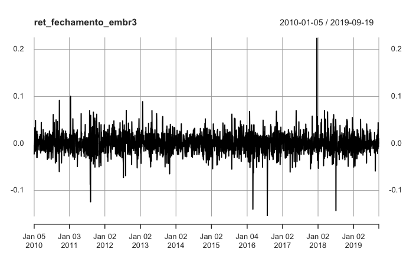

```r
ret_fechamento_embr3 <- retorno_linear(EMBR3$EMBR3.SA.Close)
plot(ret_fechamento_embr3)
```

Sua vez de exercitar. Exercício: Crie uma função que calcula o log-retorno, eq. abaixo, e plote o seu gráfico.
$$ret_t = \frac{ln(P_t)}{ln(P_{t-1})} = ln(P_t) - ln(P_{t-1})$$
.

### 3. Estatística descritiva

#### 3.1 Importando bibliotecas de manipulação de dados

Agora vamos importar as bibliotecas `tidyr` e `dplyr` para manipulação e análise de dados.

```r
library(tidyr)
library(dplyr)
library(magrittr)
```

#### 3.2 Juntando tabela de dados

Antes de juntar as tabelas, precisamos criar as variáveis de retorno de fechamento a partir da nossa lista com as informações baixadas pelo pacote `quantmod`. A junção das tabelas será realizada pelo pacote `xts` com a função `merge.xts()` que fará a busca pelo índice que é uma data.

```r
# vamos criar uma lista com as cotações de fechamento (lista_fechamento) e, em seguida, aplicaremos a funcao retorno_linear à lista_fechamento
lista_fechamento <- lapply(lista, function(x) x[,4])
lista_ret_fechamento <- lapply(lista_fechamento, retorno_linear)

# realizar um loop para criar objetos com o seu próprio ticker
for (i in seq(lista_ret_fechamento)){
  assign(paste0(names(listaf)[i], "_ret"), lista_ret_fechamento[[i]])
}

# juntando as tabelas e salvando como um objeto
dados_ret <- merge.xts(EMBR3_ret, ITUB3_ret, PETR3_ret, VALE3_ret)
```

Antes de realizar o empilhamento, precisamos transformar a tabela `dados_ret` em um `data frame`.

```r
# transformando em um data frame e removendo o nome das linhas
df_ret <- data.frame(data = index(dados_ret), dados_ret)
rownames(df_ret) <- NULL
# vendo a estrutura dos dados
str(df_ret)
```

```
'data.frame':   2411 obs. of  5 variables:
 $ data          : Date, format: "2010-01-05" "2010-01-06" "2010-01-07" ...
 $ EMBR3.SA.Close: num  -0.0233 -0.00415 -0.01354 -0.00211 0.00952 ...
 $ ITUB3.SA.Close: num  0.00161 0 -0.00965 -0.01136 -0.01478 ...
 $ PETR3.SA.Close: num  -0.006 0.0099 -0.00598 -0.00746 0.00097 ...
 $ VALE3.SA.Close: num  0.00932 0.02117 0.00415 0.00976 -0.00297 ...
```

```r
# vendo as 6 primeiras linhas
head(df_ret)
```

|  | data | EMBR3.SA.Close | ITUB3.SA.Close | PETR3.SA.Close | VALE3.SA.Close |
| --- | --- | --- | --- | --- | --- |
| 1 | 2010-01-05 | -0.023302938 | 0.001605556 | -0.0060024007 | 0.009322179 |
| 2 | 2010-01-06 | -0.004149378 | 0.000000000 | 0.0099033570 | 0.021166038 |
| 3 | 2010-01-07 | -0.013541667 | -0.009646143 | -0.0059794306 | 0.004145487 |
| 4 | 2010-01-08 | -0.002111932 | -0.011358694 | -0.0074591192 | 0.009757928 |
| 5 | 2010-01-11 | 0.009523810 | -0.014778005 | 0.0009697212 | -0.002973406 |
| 6 | 2010-01-12 | 0.033542977 | 0.009999780 | -0.0125938723 | -0.002795937 |

#### 3.3 Tornando os dados no formato long

Quando falamos que os dados no formato long (empilhados), isto é, quando cada coluna representa uma variável e teremos várias empresas para vários anos. Esse formato é o mais adequado para trabalhar com o pacote dplyr e ggplot2, conforme o próprio criador Hadley Wickham.

A função **gather()** transforma as colunas em linhas criando uma variável que representará as colunas. A informação da data eu retiro para que ela não seja empilhada com as demais.

```r
df <- gather(df_ret, key = acao, value = retorno, -data)
df
```

| data | acao | retorno |
| --- | --- | --- |
| 2010-01-05 | EMBR3.SA.Close | -0.0233029382 |
| 2010-01-06 | EMBR3.SA.Close | -0.0041493776 |
| 2010-01-07 | EMBR3.SA.Close | -0.0135416667 |
| 2010-01-08 | EMBR3.SA.Close | -0.0021119324 |
| 2010-01-11 | EMBR3.SA.Close | 0.0095238095 |
| 2010-01-12 | EMBR3.SA.Close | 0.0335429769 |
| 2010-01-13 | EMBR3.SA.Close | -0.0101419878 |
| 2010-01-14 | EMBR3.SA.Close | -0.0092213115 |
| 2010-01-15 | EMBR3.SA.Close | 0.0093071355 |
| 2010-01-18 | EMBR3.SA.Close | -0.0163934426 |

[output cut: 990 more lines]

#### 3.4 Estatísticas com dplyr

O próximo passo é o de calcular as estatísticas descritivas. Utilizaremos o pacote **dplyr** que é o que permite a manipulação de dados ao mesmo tempo em que se cria tabelas com as estatísticas.

Vamos omitir os dados faltantes, faremos agrupamento pelas ações e apresentaremos a quantidade de observações (n), média, mediana, desvio-padrão, mínimo e máximo.

```r
df %>%
  na.omit() %>%
  group_by(acao) %>%
  summarize(n = n(), media = mean(retorno), mediana = median(retorno), desvpad = sd(retorno), min = min(retorno), max = max(retorno))
```

| acao | n | media | mediana | desvpad | min | max |
| --- | --- | --- | --- | --- | --- | --- |
| EMBR3.SA.Close | 2385 | 0.0005784717 | 0.0000000000 | 0.02080595 | -0.1545040 | 0.2249849 |
| ITUB3.SA.Close | 2395 | 0.0005213800 | 0.0003241281 | 0.01804171 | -0.1205650 | 0.1174699 |
| PETR3.SA.Close | 2389 | 0.0006982373 | 0.0000000000 | 0.04802825 | -0.6290540 | 1.8030303 |
| VALE3.SA.Close | 2387 | 0.0003233199 | 0.0000000000 | 0.02597581 | -0.2455922 | 0.1476138 |

### 4. Análise exploratória

A análise exploratória realizada a seguir representa a etapa de criação de gráficos.

O primeiro gráfico será o de linha, em que plotaremos o retorno das ações ao longo do tempo. Em seguida faremos o histograma e o boxplot.

#### 4.1 Importando a biblioteca ggplot2

A biblioteca utilizada para criar os gráficos é **ggplot2**, a qual carregaremos abaixo.

```r
library(ggplot2)
```

#### 4.2 Gráfico das séries temporais

Para criar o gráfico da série temporal com o ggplot2, utilizaremos a função `geom_line()`.

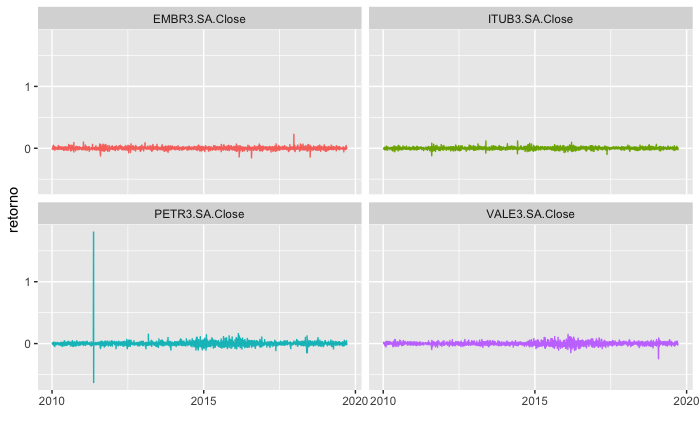

```r
g1 <-  ggplot(df, aes(data, retorno, color = as.factor(acao))) +
  geom_line() +
  #scale_x_date(date_labels =  "%d/%m/%Y", date_breaks = "1 year") +
  xlab("") +
  guides(col = FALSE) +
  facet_wrap(~acao)
g1
```

#### 4.3 Histograma

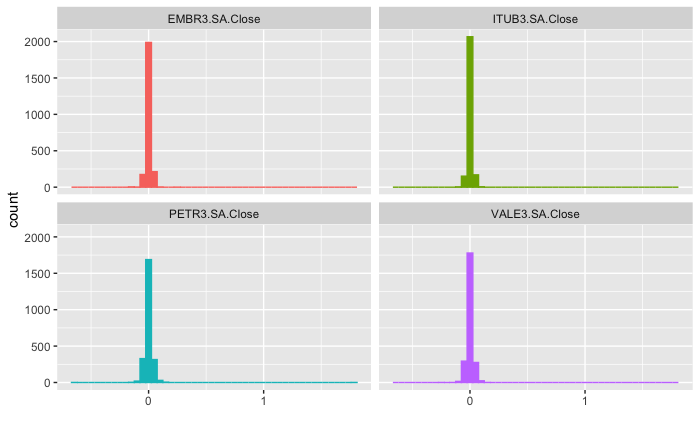

```r
# todos com facet
g2 <-  ggplot(df, aes(retorno, color = acao, fill = acao)) +
  geom_histogram(bins = 50) +
  xlab("") +
  guides(col = FALSE, fill = FALSE) +
  facet_wrap(~acao)

g2
```

#### 4.4 Box-plot

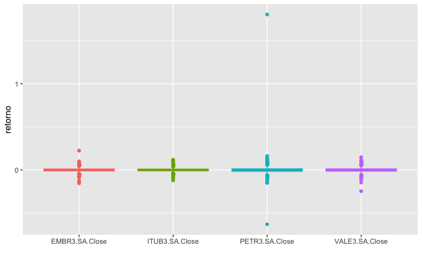

```r
g3 <-  ggplot(df, aes(acao,retorno, color = acao, fill = acao)) +
  geom_boxplot() +
  xlab("") +
  guides(color = FALSE, fill = FALSE)

g3
```

Vamos remover os outliers para visualizar melhor os gráficos

```r
df2 <- df %>%
filter(retorno > -0.5, retorno < 1)
```

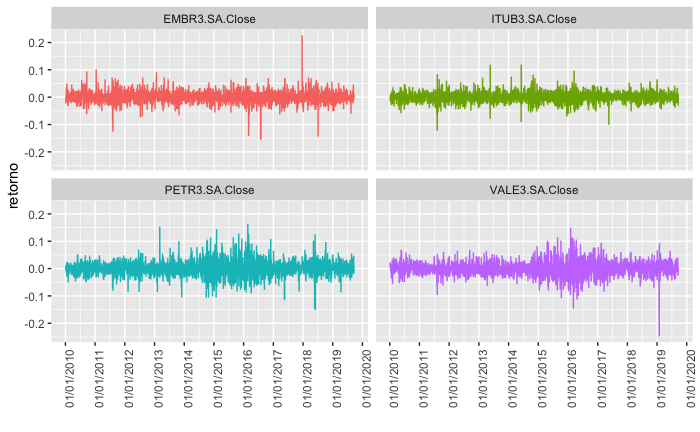

```r
g4 <-  ggplot(df2, aes(data, retorno, color = as.factor(acao))) +
  geom_line() +
  scale_x_date(date_labels =  "%d/%m/%Y", date_breaks = "1 year") +
  xlab("") +
  guides(color = FALSE) +
  theme(axis.text.x = element_text(angle = 90, hjust = 1)) +
  facet_wrap(~acao)
g4
```

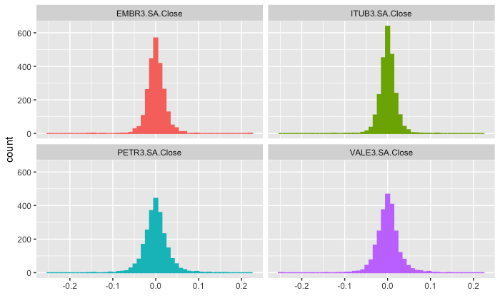

```r
g2 <-  ggplot(df2, aes(retorno, color = acao, fill = acao)) +
  geom_histogram(bins = 50) +
  xlab("") +
  guides(color = FALSE, fill = FALSE) +
  facet_wrap(~acao)

g2
```

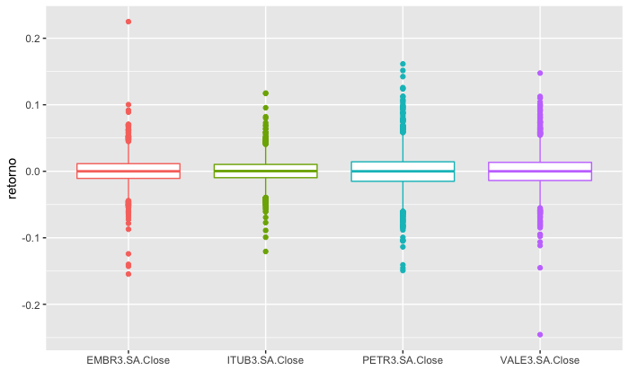

```r
g3 <-  ggplot(df2, aes(acao,retorno, color = acao)) +
  geom_boxplot() +
  xlab("") +
  guides(color = FALSE)

g3
```